```python
import pandas as pd
import numpy as np
import sklearn
from sklearn import preprocessing

from sklearn.naive_bayes import GaussianNB

from sklearn.discriminant_analysis import LinearDiscriminantAnalysis

from sklearn.feature_selection import VarianceThreshold

from sklearn.ensemble import RandomForestClassifier
from sklearn.datasets import make_classification
from sklearn.ensemble import ExtraTreesClassifier
from sklearn.ensemble import AdaBoostClassifier
from xgboost import XGBClassifier

from sklearn.model_selection import train_test_split

import matplotlib
%matplotlib inline
import matplotlib.pyplot as plt
import seaborn as sns
plt.style.use('fivethirtyeight')

from sklearn.model_selection import train_test_split
import random
import sys
import time
from sklearn.model_selection import train_test_split
from sklearn import preprocessing
from sklearn.preprocessing import StandardScaler
from sklearn.metrics import classification_report
from sklearn.metrics import confusion_matrix
from sklearn.metrics import mean_squared_error
from sklearn.pipeline import Pipeline
from sklearn.model_selection import GridSearchCV
from sklearn.model_selection import RandomizedSearchCV
from sklearn.metrics import accuracy_score
from sklearn.metrics import roc_auc_score
from sklearn.model_selection import StratifiedKFold
from sklearn.ensemble import RandomForestClassifier
from sklearn.ensemble import AdaBoostClassifier
import scikitplot as skplt
from xgboost.sklearn import XGBClassifier
from xgboost import plot_importance

import sklearn
from sklearn import datasets, linear_model
from sklearn.model_selection import train_test_split
from sklearn.metrics import mean_squared_error, r2_score
from numpy.polynomial.polynomial import polyfit
from sklearn.preprocessing import PolynomialFeatures
from sklearn import linear_model
from sklearn.model_selection import KFold

from sklearn.linear_model import LinearRegression
from sklearn import linear_model
from sklearn.model_selection import train_test_split
from sklearn.model_selection import KFold
from sklearn.model_selection import cross_val_score, cross_val_predict
from sklearn.preprocessing import StandardScaler

from sklearn import metrics
#from mlxtend.plotting import plot_learning_curves

import scipy
from scipy import stats
import os
import os.path
from IPython.display import display, HTML
from datetime import datetime
import statsmodels.api as sm
import statsmodels.tsa as smts
from statsmodels.tsa.stattools import adfuller

import requests
import re
import telnetlib
import multiprocessing
```

```python
### Music Challange Report
```

```python
#Index
```

# Music Challange Outlook

### 1. Analysis phase

```
1.1 Preliminary Problem definition

1.2 Data Exploration and Preprocessing
    1.2.1 Data Integrity
    1.2.2 Descriptive Statistics
    1.2.3 Features Analysis
    1.2.4 Dependent Variable Imbalance

1.3 Research Question and Experimental Design
    1.3.1 Model Selection
    1.3.2 Categorical Encodings
    1.3.3 Data Normalization
```

### 2. Design and Implementation phase

[output not shown]

# Analysis Phase

## 1.1 Preliminary Problem Definition

This phase is the first approach to the problem, to have a general understanding and a first overlook

The goal is to predict the tracks that would be listened, given the features in the dataset. The dataset is cross sectional. The evaluation metric is a ROC-AUC curve.

So the framework would be that of a binary classification model to approximate the music preference function for a user.

## 1.2 Data Exploration and Preprocessing

Checking for the structural integrity of the dataset, the statistical consistency of our feature and to look at the context they are used. The goal of this phase is analyze the statistical properties of the dataset and to familiarize with the features, and group them in a contextual perspective.

I'll stick to procedural programming for sketching purposes. Coding cells will be collapsed and I'll stick to minimal comments in the code as well

```python
#General imports
import numpy as np
import pandas as pd
import seaborn as sns

from sklearn import preprocessing
import category_encoders as ce


#Custom utility functions
def NaN_counter (df):
    """
    DataFrame parser for NaN:
    input: df = dataframe
    prints the number of NaN by columns
    output: returns the same df with the number of NaNs per column
    """
    print ("Running NaN Counter from the util.py module!!!!")
    import seaborn as sns
    import pandas as pd

    col = df.columns
    cont = []
    print("NaN Counter by columns")
    for i in col:
        n = len(df[(df[i].isnull() == True)])
        cont.append(n)
        if ( n != 0):
            print(i,":",len(df[(df[i].isnull() == True)]))
    df_r = pd.DataFrame([cont], columns=col)

    try:
        col_d = df_r.columns
        sns.barplot(data=df_r, orient='h').set_title('NaN per feature')
        plt.xticks(rotation=90)
    except:
        pass
    return df_r
```

```python
#Loading Dataset
df0 = pd.read_csv("/home/clemente/hub/Gen_Tech/Datasets/Music_Kgg/train.csv")
```

### 1.2.1 Data Integrity

All the features are integers, no NaNs. Curated dataset.

```python
df0.head()
```

|  | genre_id | ts_listen | media_id | album_id | context_type | release_date | platform_name | platform_family | media_duration | listen_type | user_gender | user_id | artist_id | user_age | is_listened |
| --- | --- | --- | --- | --- | --- | --- | --- | --- | --- | --- | --- | --- | --- | --- | --- |
| 0 | 25471 | 1480597215 | 222606 | 41774 | 12 | 20040704 | 1 | 0 | 223 | 0 | 0 | 9241 | 55164 | 29 | 0 |
| 1 | 25571 | 1480544735 | 250467 | 43941 | 0 | 20060301 | 2 | 1 | 171 | 0 | 0 | 16547 | 55830 | 30 | 1 |
| 2 | 16 | 1479563953 | 305197 | 48078 | 1 | 20140714 | 2 | 1 | 149 | 1 | 1 | 7665 | 2704 | 29 | 1 |
| 3 | 7 | 1480152098 | 900502 | 71521 | 0 | 20001030 | 0 | 0 | 240 | 0 | 1 | 1580 | 938 | 30 | 0 |
| 4 | 7 | 1478368974 | 542335 | 71718 | 0 | 20080215 | 0 | 0 | 150 | 0 | 1 | 1812 | 2939 | 24 | 1 |

```python
df0.info()
```

```
<class 'pandas.core.frame.DataFrame'>
RangeIndex: 7558834 entries, 0 to 7558833
Data columns (total 15 columns):
genre_id           int64
ts_listen          int64
media_id           int64
album_id           int64
context_type       int64
release_date       int64
platform_name      int64
platform_family    int64
media_duration     int64
listen_type        int64
user_gender        int64
user_id            int64
artist_id          int64
user_age           int64
is_listened        int64
dtypes: int64(15)
memory usage: 865.0 MB
```

```
Running NaN Counter from the util.py module!!!!
NaN Counter by columns
```

|  | genre_id | ts_listen | media_id | album_id | context_type | release_date | platform_name | platform_family | media_duration | listen_type | user_gender | user_id | artist_id | user_age | is_listened |
| --- | --- | --- | --- | --- | --- | --- | --- | --- | --- | --- | --- | --- | --- | --- | --- |
| 0 | 0 | 0 | 0 | 0 | 0 | 0 | 0 | 0 | 0 | 0 | 0 | 0 | 0 | 0 | 0 |

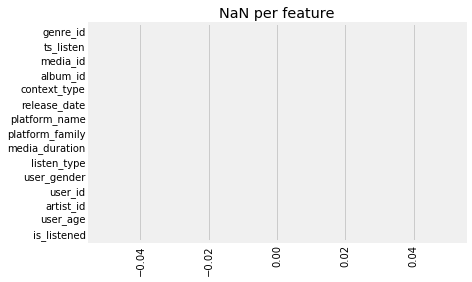

```python
NaN_counter(df0)
```

### 1.2.2 Descriptive Statistics

Many variables are numerical non ordinal ( int64). Most of them are encodings of categorical non-ordinal.

The first and second moment will not carry meaningful information. The distance between non-ordinal levels and their variability is not useful for the prediction

The media duration features has 179 entries with a 0 value. Removing the inconsistent entries.

```python
print ("Dataset Lenght: ", len(df0))

df0.describe()
```

```
Dataset Lenght:  7558834
```

|  | genre_id | ts_listen | media_id | album_id | context_type | release_date | platform_name | platform_family | media_duration | listen_type | user_gender | user_id | artist_id | user_age | is_listened |
| --- | --- | --- | --- | --- | --- | --- | --- | --- | --- | --- | --- | --- | --- | --- | --- |
| count | 7.558834e+06 | 7.558834e+06 | 7.558834e+06 | 7.558834e+06 | 7.558834e+06 | 7.558834e+06 | 7.558834e+06 | 7.558834e+06 | 7.558834e+06 | 7.558834e+06 | 7.558834e+06 | 7.558834e+06 | 7.558834e+06 | 7.558834e+06 | 7.558834e+06 |
| mean | 2.245030e+03 | 1.479011e+09 | 7.839624e+07 | 8.136169e+06 | 2.360018e+00 | 2.011388e+07 | 4.731900e-01 | 2.558086e-01 | 2.311527e+02 | 3.068742e-01 | 3.936884e-01 | 4.037300e+03 | 1.500740e+06 | 2.431278e+01 | 6.840330e-01 |
| std | 1.308979e+04 | 1.189935e+07 | 5.133633e+07 | 5.460090e+06 | 4.659856e+00 | 7.570138e+04 | 7.353008e-01 | 5.481663e-01 | 7.999463e+01 | 4.611968e-01 | 4.885672e-01 | 3.954754e+03 | 2.519546e+06 | 3.767797e+00 | 4.648999e-01 |
| min | 0.000000e+00 | 1.000000e+00 | 2.000580e+05 | 1.976000e+03 | 0.000000e+00 | 1.900010e+07 | 0.000000e+00 | 0.000000e+00 | 0.000000e+00 | 0.000000e+00 | 0.000000e+00 | 0.000000e+00 | 1.000000e+00 | 1.800000e+01 | 0.000000e+00 |
| 25% | 0.000000e+00 | 1.478460e+09 | 1.376614e+07 | 1.255566e+06 | 0.000000e+00 | 2.009123e+07 | 0.000000e+00 | 0.000000e+00 | 1.960000e+02 | 0.000000e+00 | 0.000000e+00 | 8.990000e+02 | 2.605000e+03 | 2.100000e+01 | 0.000000e+00 |
| 50% | 3.000000e+00 | 1.479057e+09 | 9.380660e+07 | 9.525626e+06 | 1.000000e+00 | 2.014103e+07 | 0.000000e+00 | 0.000000e+00 | 2.220000e+02 | 0.000000e+00 | 0.000000e+00 | 2.738000e+03 | 1.941720e+05 | 2.500000e+01 | 1.000000e+00 |
| 75% | 2.700000e+01 | 1.479742e+09 | 1.262592e+08 | 1.329221e+07 | 2.000000e+00 | 2.016061e+07 | 1.000000e+00 | 0.000000e+00 | 2.540000e+02 | 1.000000e+00 | 1.000000e+00 | 6.064000e+03 | 1.519461e+06 | 2.800000e+01 | 1.000000e+00 |
| max | 2.597310e+05 | 1.480636e+09 | 1.372601e+08 | 1.472086e+07 | 7.300000e+01 | 3.000010e+07 | 2.000000e+00 | 2.000000e+00 | 6.553500e+04 | 1.000000e+00 | 1.000000e+00 | 1.991700e+04 | 1.144741e+07 | 3.000000e+01 | 1.000000e+00 |

```python
df0[df0['media_duration'] == 0].head()
```

|  | genre_id | ts_listen | media_id | album_id | context_type | release_date | platform_name | platform_family | media_duration | listen_type | user_gender | user_id | artist_id | user_age | is_listened |
| --- | --- | --- | --- | --- | --- | --- | --- | --- | --- | --- | --- | --- | --- | --- | --- |
| 119081 | 215245 | 1477979474 | 85833267 | 8656389 | 0 | 20120101 | 1 | 0 | 0 | 0 | 0 | 3908 | 6395700 | 26 | 1 |
| 119082 | 215245 | 1478764819 | 85833267 | 8656389 | 0 | 20120101 | 1 | 0 | 0 | 0 | 0 | 3908 | 6395700 | 26 | 0 |
| 119083 | 215245 | 1479233500 | 85833267 | 8656389 | 0 | 20120101 | 1 | 0 | 0 | 0 | 0 | 3908 | 6395700 | 26 | 0 |
| 119084 | 215245 | 1478898436 | 85833267 | 8656389 | 0 | 20120101 | 1 | 0 | 0 | 0 | 0 | 3908 | 6395700 | 26 | 0 |
| 566515 | 0 | 1478266454 | 103346690 | 10743612 | 0 | 20150101 | 0 | 0 | 0 | 0 | 1 | 2890 | 98095 | 25 | 1 |

### 1.2.3 Feature Analysis

The dataset is clean and intact but there are several problems to be solved before the modeling phase.

The first one is the data imbalance for the single observation:

From a context perspective the dataset is comprised of user-oriented features and song-oriented features, plus the dependent variable. It is important to notice that it represents several users across several songs, but since the model would be approximating the preference's function for a single user, we can assume that those are somewhat constant for different songs. One of the most alarming discrepancies is the difference between the min-max of entries per user. -Given time I would understand the preferences, profile the users and cluster in groups omogenous groups.-

A solution will be downsampling users with extremely high entries to avoid building a model that overepresents the preferences of a single one. To go about it I will restrict the dataset only to users around a certain range of entries ( plus or minus one standard deviation from the mean)

The second problem are the categorical non-ordinal variables. To run meaningful descriptive statistics I'd need to separate the numerical non-ordinal variables, from the numerical ordinal ( duration, ts_listen, age).

Ultimately to avoid the misrepresentation trap, I'd encode the numerical non-ordinal.

To understand the informative value carried by the single non-ordinal features, I'd look at the numerosity of levels per each variable. It turns out that there's a marked discrepancy among them:

```python
df0 = df0[df0['media_duration'] != 0]
```

```python
y = df0['is_listened']
X_ord = df0[['ts_listen','media_duration','user_age','release_date']]
X_nom = df0.drop(columns=['ts_listen','media_duration','user_age','release_date','is_listened'])
```

```python
x_a = []
y_a = []
for el in X_nom.columns:
    y_a.append(len(X_nom[el].unique()))
    x_a.append(el)
```

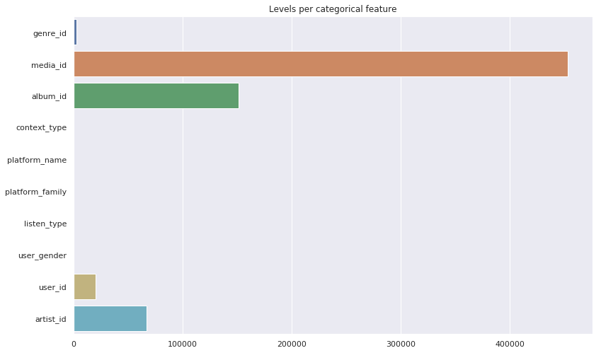

```python
sns.set(rc={'figure.figsize':(11.7,8.27)})
sns.barplot(x=y_a, y=x_a, orient='h').set_title('Levels per categorical feature')
```

```python
user_entries = ((X_nom['user_id'].value_counts()))
print("Users Entries Descriptive Stats: \n")
print(user_entries.describe())
```

```
Users Entries Descriptive Stats:

count    19918.000000
mean       379.488653
std        508.256958
min          1.000000
25%         66.000000
50%        197.000000
75%        495.000000
max       6317.000000
Name: user_id, dtype: float64
```

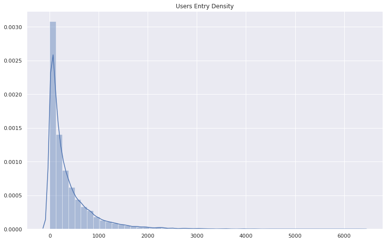

```python
sns.distplot(user_entries.values).set_title('Users Entry Density')
```

### 1.3 Research Question and Theory

#### 1.3.1 Model Selection

The literature about the "music preferences", while providing some insight on feature's importance (Schàfer 2009), doesn't define an ideal preference function. Its variability though it's very high in some of the studies and strongly depends on the genre and the usage ( Lee 2004, Lamont 2010). According to that we could relax our assumption of a constant preference function per user and keep the user-id imbalance in the dataset.

I will opt for Decision Tree model ( Random Forest - XG Boost) as a benchmark, as it grants more control over the feature's importance. A Neural Network (14 input layer to a 2 neuron output) would be a second choice, altough the dataset is way too small.

References:

[Schäfer, T. and Sedlmeier, P., 2009. From the functions of music to music preference. Psychology of Music, 37(3), pp.279-300.](https://journals.sagepub.com/doi/abs/10.1177/0305735608097247)

[Lee, J.H. and Downie, J.S., 2004, October. Survey Of Music Information Needs, Uses, And Seeking Behaviours: Preliminary Findings. In ISMIR (Vol. 2004, p. 5th).](https://citeseerx.ist.psu.edu/viewdoc/download?doi=10.1.1.536.7593&rep=rep1&type=pdf)

[Lamont, A. and Webb, R., 2010. Short-and long-term musical preferences: what makes a favourite piece of music?. Psychology of Music, 38(2), pp.222-241.](https://journals.sagepub.com/doi/abs/10.1177/0305735609339471)

#### 1.3.2 Categorical Encodings

For how to deal with categorical encodings we will refer to Potdar (2017).

Decision Trees' result are consistent with categoricals and ordinal variables. Altough an encoding is needed to convert the numerical non-ordinal into categorical non-ordinal. I'll try several methods of encodings The first one will be this "simple" conversion to change integers into labels. It will be used as a benchmark.

The second one will be binary encodings as recommended by Potdar (2017). It is a better choice than the one-hot encodings for Decision Tree models because, even though it doesn't solve the problem of the discrepancies between levels across the variables, it is less dense and avoids the curse of dimensionality problem.

References:

Potdar, K., Pardawala, T.S. and Pai, C.D., 2017. A comparative study of categorical variable encoding techniques for neural network classifiers. International Journal of Computer Applications, 175(4), pp.7-9.

#### 1.3.3 Logistic Encodings

As a third encoding option, I'd like to try and convert the numerical non-ordinal as numerical ordinal by substituting every label for each feature with its percentage likelihood of being closer to 1 or 0.

#### 1.3.4 Data Normalization

Data Normalization and Scaling will be applied to numerical ordinal variables.

The dataset presents several outliers per features.

| For computational time reasons I will be skipping outliers removal and distributions plotting for the moment |

```python
X_ord.describe()
```

|  | ts_listen | media_duration | user_age | release_date |
| --- | --- | --- | --- | --- |
| count | 7.558655e+06 | 7.558655e+06 | 7.558655e+06 | 7.558655e+06 |
| mean | 1.479011e+09 | 2.311582e+02 | 2.431276e+01 | 2.011388e+07 |
| std | 1.189949e+07 | 7.998767e+01 | 3.767797e+00 | 7.570174e+04 |
| min | 1.000000e+00 | 1.000000e+00 | 1.800000e+01 | 1.900010e+07 |
| 25% | 1.478460e+09 | 1.960000e+02 | 2.100000e+01 | 2.009123e+07 |
| 50% | 1.479057e+09 | 2.220000e+02 | 2.500000e+01 | 2.014103e+07 |
| 75% | 1.479742e+09 | 2.540000e+02 | 2.800000e+01 | 2.016061e+07 |
| max | 1.480636e+09 | 6.553500e+04 | 3.000000e+01 | 3.000010e+07 |

```python
scaler = preprocessing.StandardScaler().fit(X_ord)
X_ord_V = scaler.transform(X_ord)
```

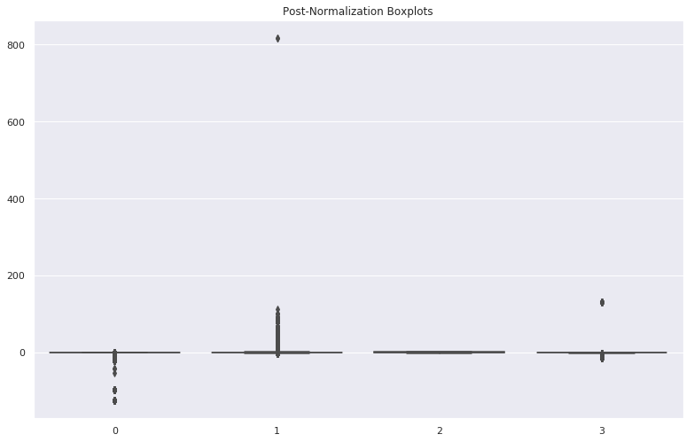

```python
sns.boxplot(data = X_ord_V).set_title('Post-Normalization Boxplots')
```

### 2 Implementation Phase

#### Re-sampling

```python
#Repacking Ordinal Dataframe after scaling
names = X_ord.columns
d = {}
l = []
n = []
for j in range(0, len(names)):
    print('Repacking: ', names[j])
    for i in range(0, len(X_ord_V)):
        l.append((X_ord_V[i][j]))
    n.append(l)

d = {
    'ts_listen':n[0],
    'media_duration': n[1],
    'user_age': n[2],
    'release_date': n[3]}

#df_ord holds the ordinal numeric variables after scaling
df_ord = pd.DataFrame(d)
```

```
Repacking:  ts_listen
Repacking:  media_duration
Repacking:  user_age
Repacking:  release_date
```

```python
#df_ord.to_pickle('df_ord')
#WARNING Manually merging dataframes as pd.concat will cause a #Memory Error on local IPython
df_pp_complete = X_nom
df_pp_complete['target'] = y
df_pp_complete['ts_listen'] = X_ord['ts_listen']
df_pp_complete['media_duration'] = X_ord['media_duration']
df_pp_complete['user_age'] = X_ord['user_age']
df_pp_complete['release_date'] = X_ord['release_date']
```

```python
#Resampling
a = len(df_pp_complete[df_pp_complete['target'] == 0])
b = len(df_pp_complete[df_pp_complete['target'] == 1])
```

```python
s = 250000*100
sample_0 = (s/a)/100
sample_1 = (s/b)/100
dfs_0 = df_pp_complete[df_pp_complete['target'] == 0].sample(frac=sample_0, replace=False, random_state=1)
dfs_1 = df_pp_complete[df_pp_complete['target'] == 1].sample(frac=sample_1, replace=False, random_state=1)
dfpp = pd.concat([dfs_0,dfs_1], axis=0).reset_index(drop=True)
#dfpp.to_pickle('df_pp')
```

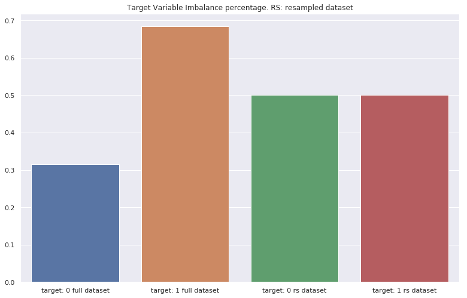

```python
#Resampling
a = len(df_pp_complete[df_pp_complete['target'] == 0])
b = len(df_pp_complete[df_pp_complete['target'] == 1])
c = len(dfpp[dfpp['target'] == 0])
d = len(dfpp[dfpp['target'] == 1])

y=[a/(a+b),(b/(a+b)),(c/(c+d)),(d/(c+d))]
d= {'target: 0 full dataset': y[0],
 'target: 1 full dataset': y[1],
 'target: 0 rs dataset': y[2],
 'target: 1 rs dataset': y[3]}

sns.barplot(data=pd.DataFrame(d, index=np.arange(0,1))).set_title('Target Variable Imbalance percentage. RS: resampled dataset')
```

### 2.2.1 Simple

Replacing numerical non-ordinal levels with strings for all the non-ordinal features.

```python
#Subselecting only numerical non-ordinal
dfpp_nom = dfpp.drop(columns=['ts_listen','media_duration','user_age','release_date'])
#Simple Encoding
dfpp_nom = dfpp_nom.applymap(str)
dfpp_SE = dfpp_nom.assign(ts_listen = dfpp['ts_listen'], media_duration = dfpp['media_duration'], user_age = dfpp['user_age'], release_date = dfpp['release_date'])
dfpp_SE.head()
```

|  | genre_id | media_id | album_id | context_type | platform_name | platform_family | listen_type | user_gender | user_id | artist_id | target | ts_listen | media_duration | user_age | release_date |
| --- | --- | --- | --- | --- | --- | --- | --- | --- | --- | --- | --- | --- | --- | --- | --- |
| 0 | 7 | 2505668 | 246245 | 1 | 0 | 0 | 1 | 0 | 9499 | 166 | 0 | 1480025020 | 266 | 20 | 19920522 |
| 1 | 0 | 97440606 | 9922006 | 3 | 0 | 0 | 0 | 1 | 11947 | 1651095 | 0 | 1480429722 | 186 | 28 | 20150309 |
| 2 | 297 | 95254400 | 9691186 | 1 | 0 | 0 | 1 | 1 | 11280 | 246791 | 0 | 1477996292 | 181 | 18 | 20150213 |
| 3 | 0 | 133637516 | 14236096 | 1 | 0 | 0 | 1 | 0 | 2013 | 314777 | 0 | 1479635551 | 161 | 30 | 20161007 |
| 4 | 25 | 64482931 | 6316633 | 0 | 1 | 0 | 0 | 0 | 3431 | 1598930 | 0 | 1480342824 | 216 | 28 | 20130212 |

```python
#Extracting X and y
X = dfpp_SE.drop(columns=['target']).values
y = dfpp_SE['target'].values
```

```
Training set has 350000 samples.
Testing set has 150000 samples.
              precision    recall  f1-score   support

           0       0.61      0.68      0.64     75004
           1       0.63      0.56      0.60     74996

   micro avg       0.62      0.62      0.62    150000
   macro avg       0.62      0.62      0.62    150000
weighted avg       0.62      0.62      0.62    150000

[[50749 24255]
 [32839 42157]]
Accuracy: 61.94%
```

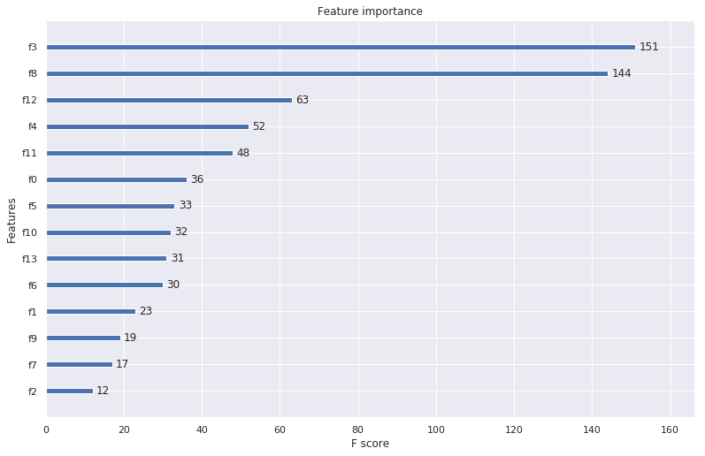

```python
#XG Boost after feature selection
X_train, X_test, y_train, y_test = train_test_split(X, y, test_size=0.3 , random_state=0)

# Show the results of the split
print("Training set has {} samples.".format(X_train.shape[0]))
print("Testing set has {} samples.".format(X_test.shape[0]))

xgb = XGBClassifier()
xgb.fit(X_train, y_train)

predictions = xgb.predict(X_test)

plot_importance(xgb)

print(classification_report(y_test,predictions))
print(confusion_matrix(y_test,predictions))
cm = confusion_matrix(y_test,predictions)
accuracy = accuracy_score(y_test, predictions)
print("Accuracy: %.2f%%" % (accuracy * 100.0))
```

```python
import numpy as np
import matplotlib.pyplot as plt

from sklearn.datasets import make_classification
from sklearn.ensemble import ExtraTreesClassifier

# Build a forest and compute the feature importances
forest = ExtraTreesClassifier(n_estimators=250,
                              random_state=0)

forest.fit(X, y)
importances = forest.feature_importances_
std = np.std([tree.feature_importances_ for tree in forest.estimators_],
             axis=0)
indices = np.argsort(importances)[::-1]

# Print the feature ranking
print("Feature ranking:")

for f in range(X.shape[1]):
    print("%d. feature %d (%f)" % (f + 1, indices[f], importances[indices[f]]))

# Plot the feature importances of the forest
plt.figure()
plt.title("Feature importances")
plt.bar(range(X.shape[1]), importances[indices],
       color="r", yerr=std[indices], align="center")
plt.xticks(range(X.shape[1]), indices)
plt.xlim([-1, X.shape[1]])
plt.show()
```

[output not shown]

### Binary Encoding

```python
ce.BinaryEncoder(cols = ['color'])
cd_bin.fit_transform(X_nom, y)
```

[output not shown]

```python
type(X_simple)
```

[output not shown]